# Time Series Analysis on GE Power Ltd stock in BSE and to Predict the closing Price of a Stcok in FUTURE

### Problem Description

Build time series models in using GE Power Stock in the BSE.Our goal is to forecast the closing price of the GEPower for future time period using time series algorithms and evaluating each of the algorithms.

### Clear the Global Environment

```r
rm(list=ls(all=TRUE))
```

### Library Call

```r
library(plyr)
```

## Read the data from csv

- Read the data using CSV for now
- GEPower_Data<-Quandl(“BSE/BOM532309”)

```r
GEPower_Data<-read.csv("C:/Users/Aishwariya Lakshmi/Downloads/BSE-BOM532309.csv")
```

## Observe the structure

```r
str(GEPower_Data)
```

```
'data.frame':   4135 obs. of  13 variables:
 $ Date                      : Factor w/ 4135 levels "2000-03-21","2000-03-22",..: 4135 4134 4133 4132 4131 4130 4129 4128 4127 4126 ...
 $ Open                      : num  624 628 615 620 616 ...
 $ High                      : num  642 631 634 625 625 ...
 $ Low                       : num  624 617 615 617 606 ...
 $ Close                     : num  630 620 632 619 622 ...
 $ WAP                       : num  631 621 628 619 618 ...
 $ No..of.Shares             : num  1128 1070 146 440 3805 ...
 $ No..of.Trades             : num  77 42 25 17 98 89 75 112 21 46 ...
 $ Total.Turnover            : num  711712 664692 91742 272504 2351233 ...
 $ Deliverable.Quantity      : num  596 679 128 238 1784 ...
 $ X..Deli..Qty.to.Traded.Qty: num  52.8 63.5 87.7 54.1 46.9 ...
 $ Spread.H.L                : num  17.9 13.8 18.9 8 19.5 ...
 $ Spread.C.O                : num  6.3 -7.8 17.1 -0.7 5.45 ...
```

## Head of the Data

```r
head(GEPower_Data)
```

|  | Date | Open | High | Low | Close | WAP | No..of.Shares | No..of.Trades | Total.Turnover | Deliverable.Quantity | X..Deli..Qty.to.Traded.Qty | Spread.H.L | Spread.C.O |
| --- | --- | --- | --- | --- | --- | --- | --- | --- | --- | --- | --- | --- | --- |
| 1 | 2017-07-05 | 624.00 | 641.70 | 623.80 | 630.30 | 630.95 | 1128 | 77 | 711712 | 596 | 52.84 | 17.90 | 6.30 |
| 2 | 2017-07-04 | 628.00 | 630.85 | 617.00 | 620.20 | 621.21 | 1070 | 42 | 664692 | 679 | 63.46 | 13.85 | -7.80 |
| 3 | 2017-07-03 | 615.05 | 634.00 | 615.05 | 632.15 | 628.37 | 146 | 25 | 91742 | 128 | 87.67 | 18.95 | 17.10 |
| 4 | 2017-06-30 | 620.00 | 625.00 | 617.00 | 619.30 | 619.33 | 440 | 17 | 272504 | 238 | 54.09 | 8.00 | -0.70 |
| 5 | 2017-06-29 | 616.05 | 625.00 | 605.50 | 621.50 | 617.93 | 3805 | 98 | 2351233 | 1784 | 46.89 | 19.50 | 5.45 |
| 6 | 2017-06-28 | 620.00 | 620.00 | 608.00 | 609.55 | 612.62 | 1700 | 89 | 1041460 | 1050 | 61.76 | 12.00 | -10.45 |

```r
tail(GEPower_Data)
```

|  | Date | Open | High | Low | Close | WAP | No..of.Shares | No..of.Trades | Total.Turnover | Deliverable.Quantity | X..Deli..Qty.to.Traded.Qty | Spread.H.L | Spread.C.O |
| --- | --- | --- | --- | --- | --- | --- | --- | --- | --- | --- | --- | --- | --- |
| 4130 | 2000-03-28 | 78.70 | 83.90 | 78.70 | 79.50 | 79.49109 | 24700 | 118 | 1963430 | NA | NA | 5.2 | 0.8 |
| 4131 | 2000-03-27 | 95.00 | 95.00 | 85.50 | 85.50 | 91.41200 | 2250 | 9 | 205677 | NA | NA | 9.5 | -9.5 |
| 4132 | 2000-03-24 | 92.70 | 93.00 | 92.70 | 92.90 | 92.83200 | 1250 | 10 | 116040 | NA | NA | 0.3 | 0.2 |
| 4133 | 2000-03-23 | 100.75 | 100.75 | 100.75 | 100.75 | 100.75000 | 400 | 6 | 40300 | NA | NA | 0.0 | 0.0 |
| 4134 | 2000-03-22 | 109.50 | 109.50 | 109.50 | 109.50 | 109.50000 | 600 | 4 | 65700 | NA | NA | 0.0 | 0.0 |
| 4135 | 2000-03-21 | 111.00 | 119.00 | 101.00 | 119.00 | 108.38000 | 500 | 6 | 54190 | NA | NA | 18.0 | 8.0 |

## Observation and Domain Knowldege

- Stock exchange is usually closed on Sunday and Holidays therefore those days cannot be taken as missing values
- Take the closing price and dates column and convert it into a new data frame

```r
GEcloseprice=GEPower_Data[,(names(GEPower_Data) %in% c("Date","Close"))]
```

## Converting the date into year ,month and day

```r
day = mdy(GEPower_Data$Date)
```

```
All formats failed to parse. No formats found.
```

```r
mth = month(GEPower_Data$Date)
yr = year(GEPower_Data$Date)
GEcloseprice = data.frame(GEcloseprice,day,yr,mth)
```

```r
a1 = group_by(GEcloseprice, yr, mth)
GEcloseprice_clean = summarise(a1, Close = mean(Close))
```

### Observation on Average Price

- The price is not changing daily very much
- We need to see mothly aggregation instead of daily
- Adding week column in addition can help in this
- use any of the following aggregations such as Min , Max or Average for the price

```r
GEcloseprice$Date=as.Date(GEcloseprice$Date,format="%Y-%m-%d")
GEcloseprice$MONTH <-as.numeric(format(GEcloseprice$Date,format="%Y.%m"))
GEcloseprice_1 <-GEcloseprice
GEcloseprice.mth1<-ddply(GEcloseprice_1 ,.(MONTH),summarise,AVG_PRICE=mean(Close))
 GEcloseprice.mth<- sqldf("select MONTH as MONTH,Avg(Close) as AVG_PRICE from GEcloseprice_1 group by MONTH")
```

### Splitting of the Data

- Random split is not possible because here we will be in need of sequence where by we miss the data points
- splitting is done by sequential splitting

```r
Train=GEcloseprice.mth[which(GEcloseprice.mth$MONTH<=2017.01),]
Test=GEcloseprice.mth[which(GEcloseprice.mth$MONTH>2017.01),]
```

### converting into time series

```r
Price <- ts(Train$AVG_PRICE, frequency =12)
```

### Vizualize the time series Data

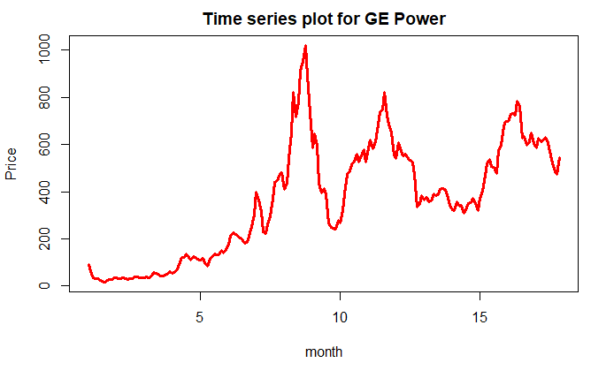

```r
plot(Price,type="l",lwd=3,col="red",xlab="month",ylab="Price",main="Time series plot for GE Power")
```

### Decomposed Time Series

- Decompose will provide us with the info on seasonality,trend and randomness

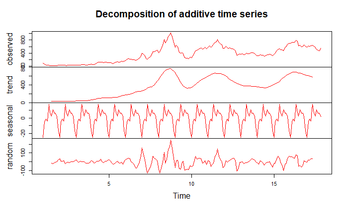

```r
Pricedecomposed=decompose(Price)
plot(Pricedecomposed,col="Red")
```

### ACF,PACF

- Autocorrelation is the linear dependence of a variable with itself at two points in time
- For stationary processes, autocorrelation between any two observations only depends on the time lag h between them
- Partial autocorrelation is the autocorrelation between yt and ytâ“h after removing any linear dependence on y1,y2, …, yth+1

```r
par(mfrow=c(2,2))
acf(Price,lag=30)
pacf(Price,lag=30)
```

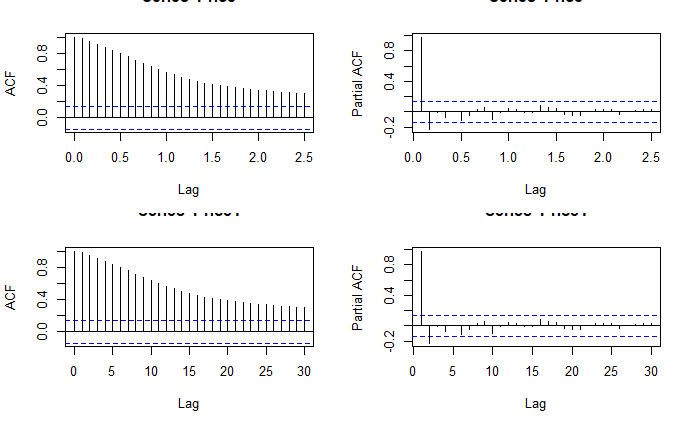

```r
Price1 <- ts(Train$AVG_PRICE, frequency =1)
acf(Price1,lag=30)
pacf(Price1,lag=30)
```

- Looking at the Y scale in ACF we observe that trend is more dominant than seasonality
- Data is not stationay and we need to stationarize the data

### Stationarize by differencing

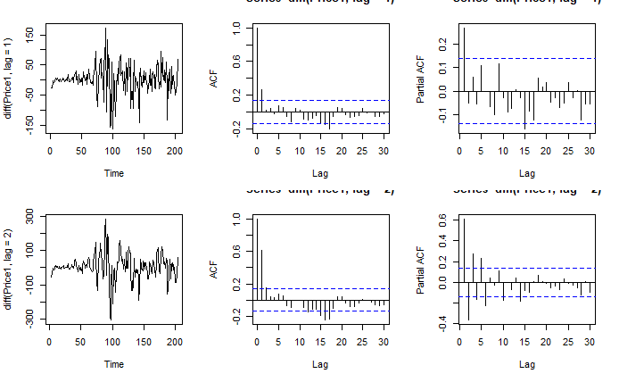

```r
par(mfrow=c(2,3))
plot(diff(Price1,lag = 1),type="l"); acf(diff(Price1,lag = 1),lag=30) ;pacf(diff(Price1,lag = 1),lag=30)
plot(diff(Price1,lag=2),type="l");  acf(diff(Price1,lag = 2),lag=30); pacf(diff(Price1,lag = 2),lag=30)
```

- one lag has stationarize the data we can use ndiffs of forecast package to check no of differences required to stationarize the data

### Modelling the time series using simple moving averages

- Time series Price has trend
- Modelling the time series behaviour by simple moving averages

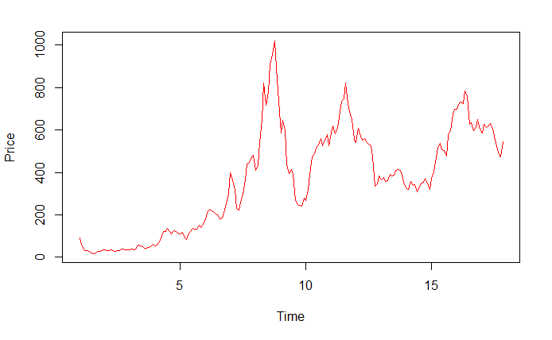

```r
plot(Price,col="red")
```

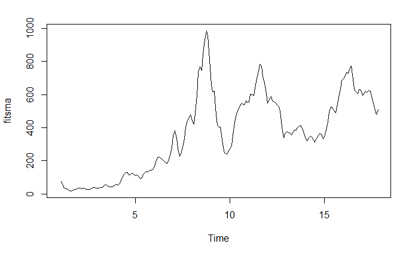

```r
fitsma <- SMA(Price,n=2)
plot(fitsma)
```

### Define the metric MAPE

```r
smaMape <- mean(abs((Price[2:length(Price)]-fitsma[2:length(Price)])/Price[2:length(Price)]))
smaMape
```

```
[1] 0.0492652
```

### Weighted Moving Averages

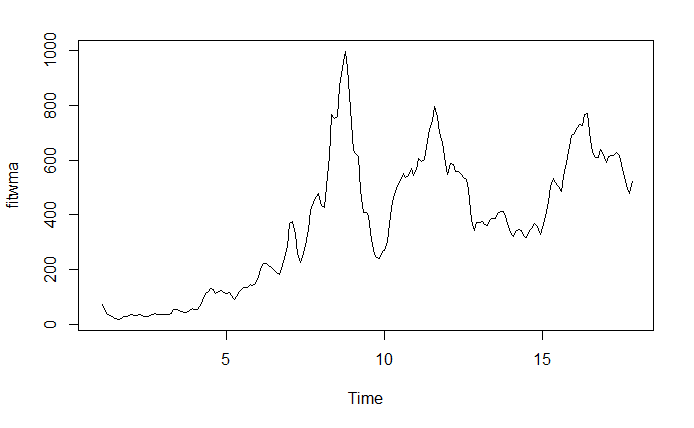

```r
fitwma<- WMA(Price,n=2,1:2)
plot(fitwma)
```

```r
wmaMape <- mean(abs((Price[2:length(Price)]-fitwma[2:length(Price)])/Price[2:length(Price)]))
wmaMape
```

```
[1] 0.03284347
```

### Exponential Moving Averages

```r
fitEma <- EMA(Price, n = 2)
emaMape <- mean(abs((Price[2:length(Price)]-fitEma[2:length(Price)])/Price[2:length(Price)]))
emaMape
```

```
[1] 0.03928863
```

## HoltWinters Model

```r
holtpriceforecast <- HoltWinters(Train$AVG_PRICE,gamma=FALSE)
head(holtpriceforecast$fitted)
```

```
Time Series:
Start = 3
End = 8
Frequency = 1
        xhat    level     trend
3 35.6875000 63.00000 -27.31250
4  9.6039599 36.81250 -27.20854
5  7.0535238 32.17619 -25.12267
6  8.3489276 31.23684 -22.88791
7  2.0891435 23.57045 -21.48131
8 -0.8993207 19.01765 -19.91697
```

## Improvement of the model

```r
priceholtforecast <-
HoltWinters(Price, beta=TRUE, gamma=TRUE, seasonal="additive")
head(priceholtforecast$fitted,24)
```

```
          xhat    level       trend     season
Jan 2 37.37298 28.74386   0.2959762   8.333143
Feb 2 30.05710 27.77243  -0.9714353   3.256106
Mar 2 32.15244 28.59446   0.8220331   2.735947
Apr 2 36.50910 29.76142   1.1669589   5.580723
May 2 30.64219 30.82057   1.0591527  -1.237533
Jun 2 29.76755 31.59619   0.7756201  -2.604259
Jul 2 19.63488 31.95243   0.3562361 -12.673780
Aug 2 40.98397 42.09419  10.1417607 -11.251981
Sep 2 39.16815 41.78933  -0.3048538  -2.316334
Oct 2 38.97353 39.70197  -2.0873613   1.358917
Nov 2 39.08767 38.46219  -1.2397807   1.865255
Dec 2 35.55561 33.53200  -4.9301895   6.953795
Jan 3 32.38704 28.82995  -4.7020563   8.259154
Feb 3 27.32537 26.39725  -2.4326911   3.360805
Mar 3 44.46414 34.05265   7.6553993   2.756083
Apr 3 40.26140 34.36981   0.3171559   5.574430
May 3 35.62344 35.62367   1.2538557  -1.254085
Jun 3 78.51165 58.38203  22.7583626  -2.628742
Jul 3 43.31732 56.90094  -1.4810917 -12.102520
Aug 3 51.28789 60.02533   3.1243919 -11.861833
Sep 3 47.77451 55.11012  -4.9152113  -2.420393
Oct 3 34.28920 43.99546 -11.1146546   1.408397
Nov 3 43.77036 43.05800  -0.9374573   1.649817
Dec 3 60.20570 48.14830   5.0902909   6.967113
```

```r
holtforecastTrain <- data.frame(priceholtforecast$fitted)
holtforecastTrainpredictions <- holtforecastTrain$xhat
head(holtforecastTrainpredictions)
```

```
[1] 37.37298 30.05710 32.15244 36.50910 30.64219 29.76755
```

### Prediction on test data

```r
priceforecast<-forecast(priceholtforecast,h = 6)
```

### Arima Models

```r
model1 <- arima(Price,c(0,0,0))
model1
```

```
Call:
arima(x = Price, order = c(0, 0, 0))

Coefficients:
      intercept
       363.0391
s.e.    17.0696

sigma^2 estimated as 59148:  log likelihood = -1403.31,  aic = 2810.61
```

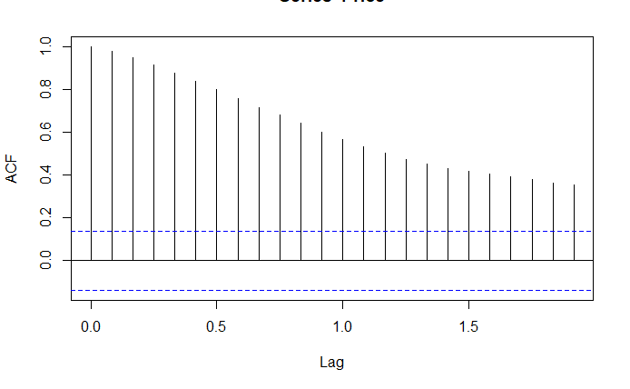

```r
acf(Price)
```

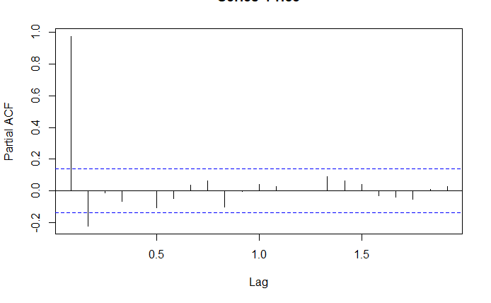

```r
pacf(Price)
```

```r
model2 <- arima(Price,c(0,1,0))
model2
```

```
Call:
arima(x = Price, order = c(0, 1, 0))


sigma^2 estimated as 2164:  log likelihood = -1062.26,  aic = 2126.51
```

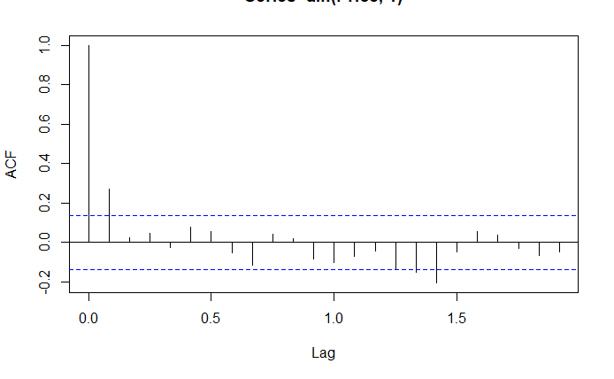

```r
acf(diff(Price,1))
```

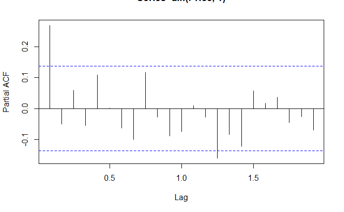

```r
pacf(diff(Price,1))
```

```r
model3 <- arima(Price,c(0,2,0))
model3
```

```
Call:
arima(x = Price, order = c(0, 2, 0))


sigma^2 estimated as 3141:  log likelihood = -1094.47,  aic = 2190.94
```

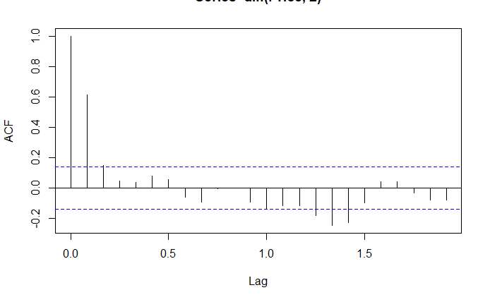

```r
acf(diff(Price,2))
```

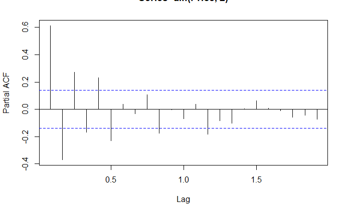

```r
pacf(diff(Price,2))
```

```r
model4 <- arima(Price,c(1,3,1))
model4
```

```
Call:
arima(x = Price, order = c(1, 3, 1))

Coefficients:
          ar1      ma1
      -0.3253  -1.0000
s.e.   0.0670   0.0125

sigma^2 estimated as 2816:  log likelihood = -1081.07,  aic = 2168.14
```

```r
par(mfrow=c(2,2))
plot(model1$residuals,ylim=c(-50,50))
plot(model2$residuals,ylim=c(-50,50))
```

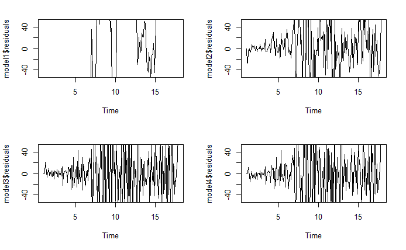

```r
plot(model3$residuals,ylim=c(-50,50))
plot(model4$residuals,ylim=c(-50,50))
```

### Using Auto Arima

```r
MODEL_ARIMA <- auto.arima(Price, ic='aic')
summary(MODEL_ARIMA)
```

```
Series: Price
ARIMA(0,1,1)

Coefficients:
         ma1
      0.2986
s.e.  0.0708

sigma^2 estimated as 2002:  log likelihood=-1053.94
AIC=2111.89   AICc=2111.95   BIC=2118.51

Training set error measures:
                   ME     RMSE      MAE       MPE     MAPE
Training set 1.801573 44.51865 29.64201 0.1722435 9.283303
                  MASE         ACF1
Training set 0.1994516 -0.004560864
```

### Forecast on the models

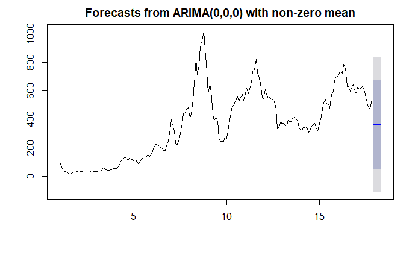

```r
pricearimaforecasts1 <- forecast(model1, h=6)
plot(pricearimaforecasts1)
```

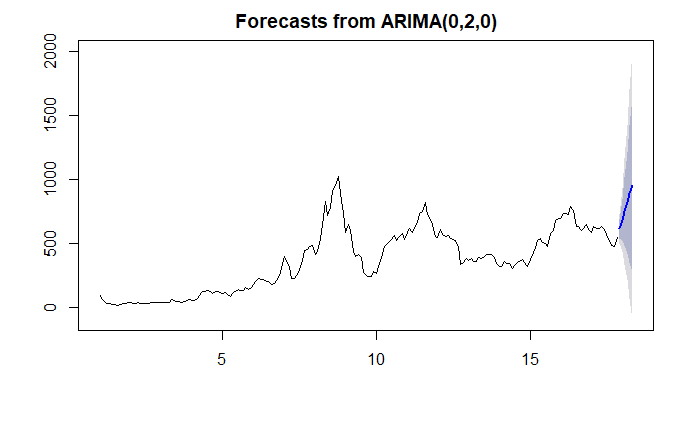

```r
pricearimaforecast3 <- forecast(model3, h=6)
plot(pricearimaforecast3)
```

```r
pricearimaforecasts_autArima<- forecast(MODEL_ARIMA,h=6)
```